# MTH6139 Time Series

Forecating the monthly Atmospheric concentrations of CO2

Arjun Dhillon

Spring term 2025

# CO2 Dataset

Atmospheric concentrations of CO2 are expressed in parts per million (ppm) and reported in the preliminary 1997 SIO manometric mole fraction scale. I will utilise this CO2 time series, with 468 monthly observations between the years 1959 to 1997, to predict any future changes in the Atmospheric concentration with the help of the `prophet` function in R.

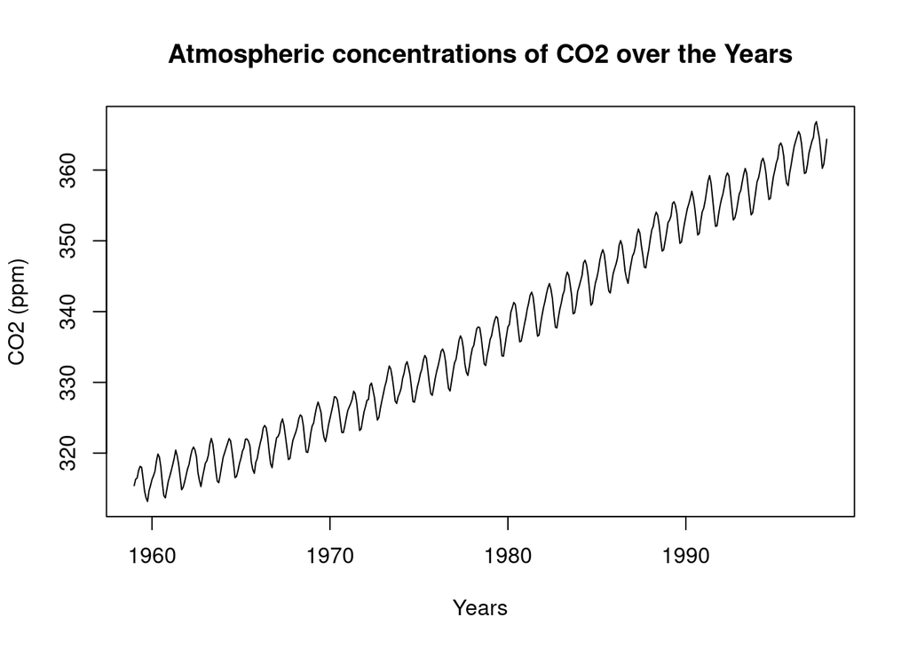

## Using the `Prophet` function

In order to forecast the CO2 dataset we will need to create a data frame. As the `prophet` function requires a structured and time-indexed format when handling data.

```r
#Creating a dataframe with CO2 values and corresponding dates
co2.df = data.frame(
    ds=zoo::as.yearmon(time(co2)),#converting time format to year-month
    y=co2)
m_co2 = prophet::prophet(co2.df)#Fitting prophet model to CO2
```

```
## Disabling weekly seasonality. Run prophet with weekly.seasonality=TRUE to override this.
```

```
## Disabling daily seasonality. Run prophet with daily.seasonality=TRUE to override this.
```

## Forecasting data

To forecast the data we need to use the `make_future_dataframe` function, which will provide a prediction based on the previous trends and seasonality of the past results.

**First we will forecast the next 8 quarter results below.**

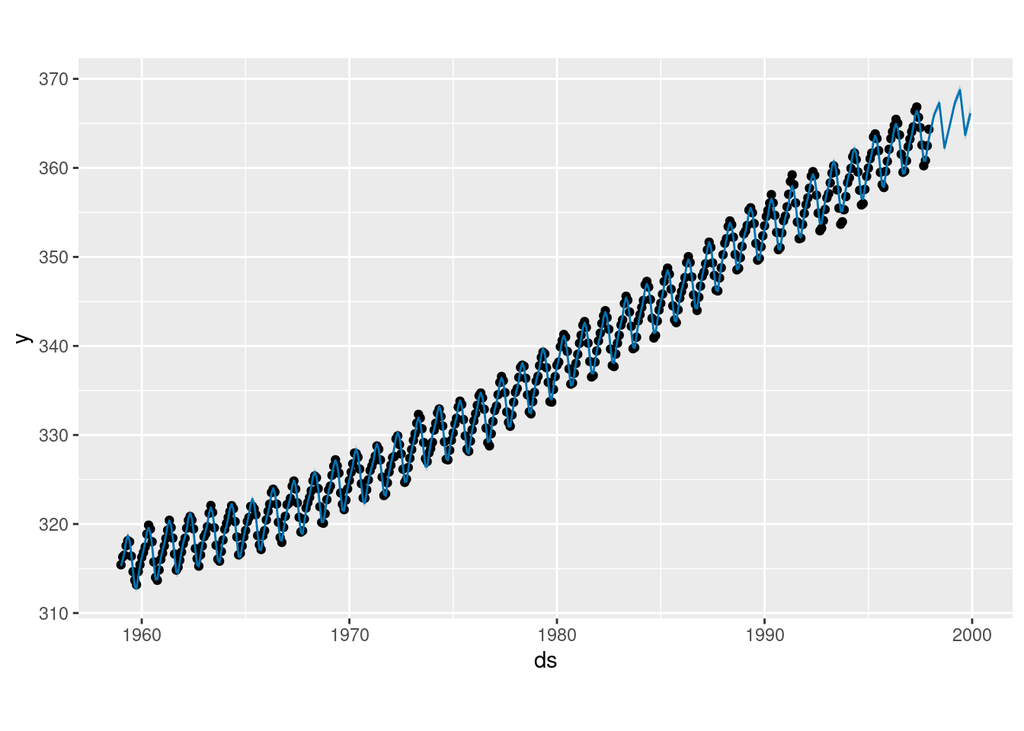

```r
#Forecasting the data frame using prophet function
#In this case 'period = 8' which means 8 quarters as the 'freq = quarter'
forecast_8quarter = prophet::make_future_dataframe(m_co2, periods=8, freq="quarter")
#Generating predictions
plot_8quarter = predict(m_co2, forecast_8quarter)
#Plotting the results along with the original data frame
plot(m_co2,plot_8quarter)
```

This forecast shows an accurate estimation of the CO2 values in the next 8 quarters, the lack of the blue shaded section shows there is little uncertainty in the results. Therefore we can conclude that there will be an upwards trend and therefore an increase in the atmospheric concentrations of CO2 in the near future.

**Now we will forecast the next 4 years below.**

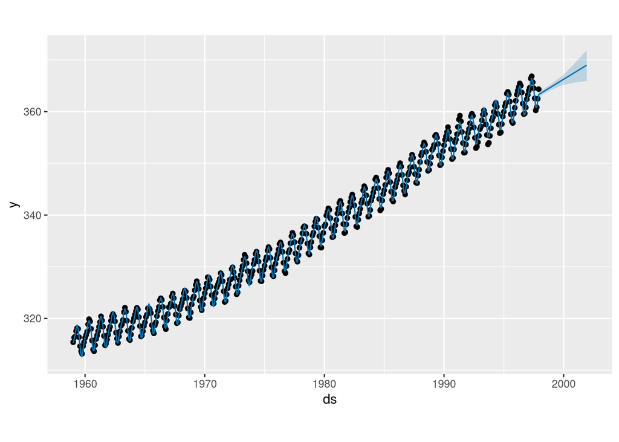

```r
#Repeating for 4 year prediction
forecast_4years = prophet::make_future_dataframe(m_co2, periods=4, freq="year")
plot_4years = predict(m_co2, forecast_4years)
plot(m_co2,plot_4years)
```

This four-year forecast plot illustrates how CO2 levels, shown by the black dots representing historical monthly measurements, are projected to continue rising. The blue line extending beyond the last data points demonstrates Prophet’s prediction for future growth, while the surrounding shaded area indicates the model’s increasing uncertainty over time. Despite only forecasting four years ahead, the figure clearly maintains the upward trend observed in the previous results.

**Lastly we forecast the next 10 years of CO2 concentration below.**

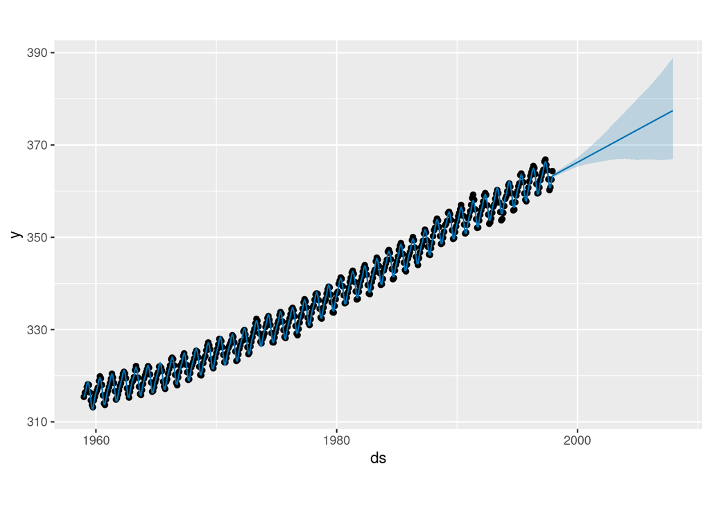

```r
#Repeating for 10 year prediction
forecast_10years = prophet::make_future_dataframe(m_co2, periods=10, freq="year")
plot_10years = predict(m_co2, forecast_10years)
plot(m_co2,plot_10years)
```

This ten-year forecast plot demonstrates how the monthly CO2 readings are predicted to evolve over the next decade. Prophet’s projected line, extending beyond the observed values, incorporates the historical upward trend. Notably, the blue shaded region expands further than in the shorter forecasts, reflecting the model’s increasing uncertainty over a longer time horizon. Despite that widening interval, the overall pattern remains a steady climb in CO2 levels, showing the continuation of the growth pattern well into the future.

**Summary**

The `prophet` function clearly forecasts increasing Atmospheric concentration in CO2 in each case, as all three plots increase in size. The dark blue line represents the forecast, and as we see in all cases they fit with the current trends of results. However there is an increase of the blue shaded section in the graphic results, as the forecast increase in size. This shows there will be uncertainty in the trend, uncertainty in the seasonal components and an increase in random noise as the forecasts increase in size. This suggests a loss of accuracy in the `prophet` function as the yearly forecasts increase.

## Trend/Seasonality Plots

Prophet has more functions to help with breaking down the trend, weekly, yearly or other seasonalities called the `prophet_plot_components` function.

I will use this function to compare how the trend and seasonality may change as the forecasted data increases in size, to see how the prophet function copes with trend/seasonality when there is an influx in forecasted data.

**Here we have the 8 quarter trend and seasonality plots.**

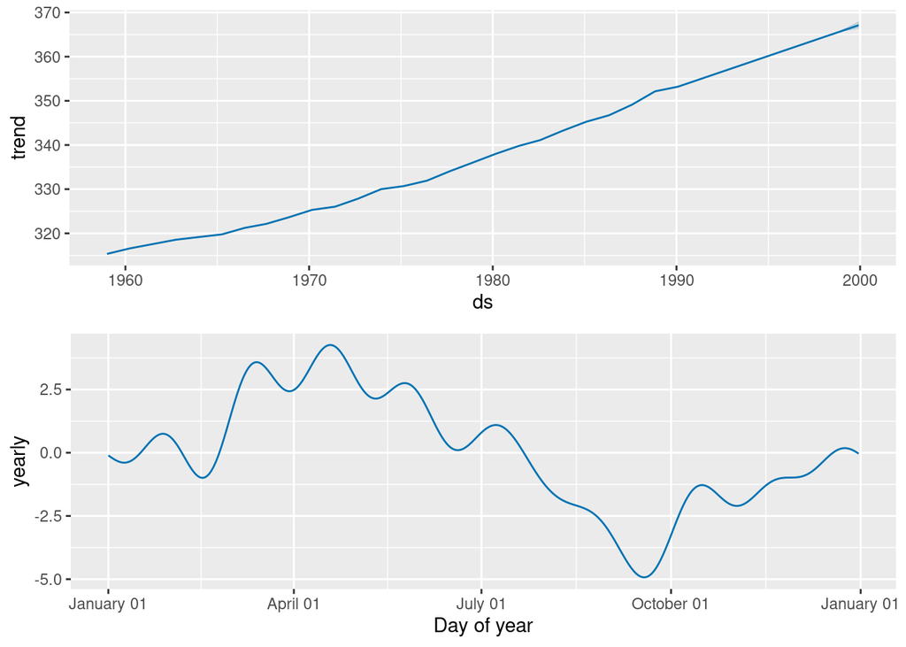

```r
prophet::prophet_plot_components(m_co2, plot_8quarter)
```

These two plots break down Prophet’s model of the CO2 dataset into its overall trend (top graph) and yearly seasonality (bottom graph). The trend plot shows a clear and steady upward trajectory in CO2 concentrations over the historical period, reflecting long-term growth. The seasonality plot reveals a repeating annual cycle: CO2 typically reaches higher levels in around April to May and dips toward its lowest values in September.

**Here we have the 4 year trend and seasonality plots.**

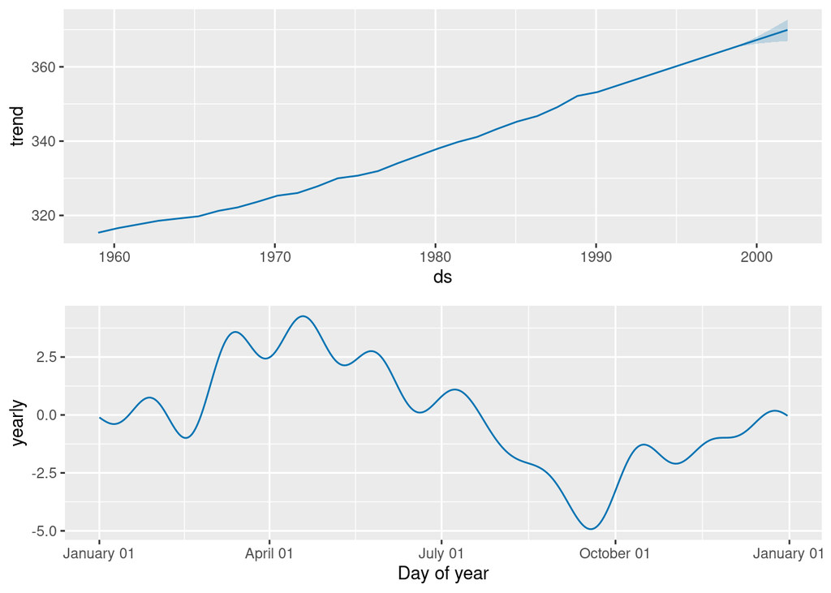

```r
prophet::prophet_plot_components(m_co2, plot_4years)
```

These two plots, showing the four-year trend and yearly seasonality, closely mirror what we observed in the eight-quarter plots, reinforcing the consistency of the model’s findings. The trend plot again reveals a steady, long-term climb in CO2 concentrations from the 1960s through 2000, while the seasonality plot retains its recognizable annual pattern of higher CO2 in the early summer and lower levels in early autumn. Thus, whether the forecast extends to four years or eight quarters, Prophet’s decomposition highlights the same behavior, a clear upward trajectory coupled with a regular fluctuations. Which indicates that the model is picking up on stable, underlying patterns in the data.

**Lastly we have the 10 year trend and seasonality plots.**

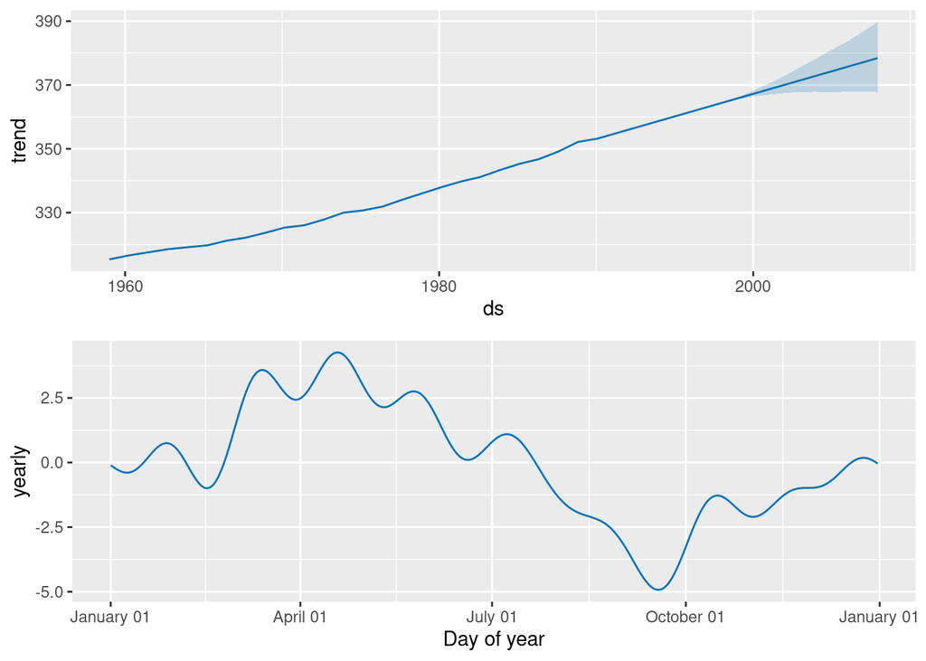

```r
prophet::prophet_plot_components(m_co2, plot_10years)
```

**Summary**

Overall, the trend of all three plots are clearly increasing and stays consistent throughout.The bottom panels show the yearly seasonal components, where typically there is a peak around April/May and a trough in early Autumn, around September/October. This means CO2 tends to be the highest mid-year and tends to be the lowest in the late summer.

Each plot shows the same behaviour, which is an upwards slope with a recurring dip in seasonality. Asking `Prophet` to forecast further extends the line accordingly, which visualises how the CO2 concentrations continue to climb over time.

## Simple Linear Regression

To determine the accuracy of the `prophet` function forecast, we compare it to the linear regression of the CO2 dataset using the `lm` function.

```
##
## Call:
## lm(formula = y ~ ds, data = co2.df)
##
## Residuals:
##     Min      1Q  Median      3Q     Max
## -6.0399 -1.9476 -0.0017  1.9113  6.5149
##
## Coefficients:
##               Estimate Std. Error t value Pr(>|t|)
## (Intercept) -2.250e+03  2.127e+01  -105.8   <2e-16 ***
## ds           1.308e+00  1.075e-02   121.6   <2e-16 ***
## ---
## Signif. codes:  0 '***' 0.001 '**' 0.01 '*' 0.05 '.' 0.1 ' ' 1
##
## Residual standard error: 2.618 on 466 degrees of freedom
## Multiple R-squared:  0.9695, Adjusted R-squared:  0.9694
## F-statistic: 1.479e+04 on 1 and 466 DF,  p-value: < 2.2e-16
```

The Linear Regression data confirms what we know from the `prophet` function. The `lm` data confirms a strong and steady growth in CO2, however unlike the `prophet` function the `lm` function does not model seasonality and therefore will not take into account the well-known seasonal pattern that the `prophet` function captures which are the peaks mid-year and the lowest points during late summer.

# Conclusion

In this project, we examined the CO2 dataset using both a simple linear model and Prophet forecasting. The data clearly show a steadily rising trend in atmospheric CO₂ over time, which the linear regression confirms with a highly significant positive slope. However, the plain linear approach cannot capture the well‐documented seasonal fluctuation—CO₂ levels peak in April/May and reach a trough in early Autumn each year.

By contrast, Prophet’s model distinguishes between a long‐term upward trend and a clear yearly seasonality pattern, which is consistent with well-known seasonal carbon cycles therefore highlighting the accuracy of the prophet function. Our forecast results suggest continued increases in CO₂ concentrations, with each additional year extending the trend even higher. These findings align with scientific consensus on rising atmospheric CO2 which further spotlights the need for time-series modelling techniques and how precise they can be when taking into account seasonality and trends.

# References

- Weather Data Source: https://www.ncei.noaa.gov/cdo-web/
- RStudio reference: https://rmarkdown.rstudio.com/lesson-1.html
- More sophisticated reference: https://bookdown.org/yihui/rmarkdown/